# Mixed-design ANOVA

ChatGPT 4o

2024-11-27

## 1 起源

混合设计的方差分析（Mixed Design ANOVA），也称为混合因素方差分析，最早由统计学家在20世纪中期发展，用于分析既包含重复测量因素又包含独立组因素的数据。它结合了独立样本设计和重复测量设计的优势，可以同时分析组间和组内效应。该方法广泛应用于社会科学、心理学和生物医学等领域，尤其适合评估多因素实验中的复杂效应。

## 2 原理

混合设计方差分析是一种同时包含**组间因素**（不同组别的个体）和**组内因素**（同一组别的个体在不同时间或条件下的测量）的统计分析方法。混合设计方差分析的核心在于分析不同因素及其交互作用对因变量的影响。

混合设计方差分析的数学模型可表示为：
$$Y_{ijk} = \mu + \alpha_i + \beta_j + (\alpha\beta)_{ij} + \epsilon_{ijk}$$
其中：

- $Y_{ijk}$ 表示第$i$组第$j$时间点第$k$个个体的观测值；
- $\mu$ 表示总体均值；
- $\alpha_i$ 表示组间因素的效应；
- $\beta_j$ 表示组内因素的效应；
- $(\alpha\beta)_{ij}$ 表示组间和组内因素的交互作用；
- $\epsilon_{ijk}$ 表示误差项。

混合设计方差分析的目标是测试组间主效应、组内主效应以及组间与组内因素的交互效应。通过分离这些不同来源的变异，混合设计方差分析能够帮助研究人员更好地理解复杂实验中的效应。

## 3 适用范围

混合设计方差分析适用于以下情况：

- **组间和组内因素同时存在**：当实验设计中包含组间因素（如不同组别的受试者）和组内因素（如同一组别在多个时间点上的重复测量）时，适合使用混合设计方差分析。
- **多因素实验**：当研究涉及多个自变量，并且自变量之间的交互效应可能对因变量产生影响时，可以使用混合设计方差分析。
- **平衡数据**：混合设计方差分析通常要求数据是平衡的，即每个组别中的观测数相同。

## 4 应用情境

混合设计方差分析在多个领域中有广泛的应用，例如：

- **心理学实验**：用于分析同一组被试者在不同时间点或不同条件下的表现，以及不同组别的比较。
- **教育学研究**：用于评估不同教学方法对学生在多个测试时间点的成绩的影响。
- **医学和生物学**：用于比较不同治疗方法在多次随访中的效果，既考虑不同组别之间的差异，也考虑随时间变化的差异。
- **市场营销**：用于评估不同客户群体对某一促销活动在多个时间点上的反应。

## 5 优缺点

### 优点

- **能够同时分析组内和组间效应**：混合设计方差分析能够在同一模型中分析组内因素和组间因素的效应，适合多因素实验。
- **检测交互作用**：能够检测组内和组间因素之间的交互作用，帮助研究人员理解不同因素的复杂关系。
- **提高统计效能**：通过重复测量，减少个体差异对结果的影响，从而提高统计效能。

### 缺点

- **数据要求高**：混合设计方差分析通常要求数据平衡，数据缺失可能导致分析复杂化或无法进行。
- **假设严格**：需要满足正态性、方差齐性等假设，尤其是组内因素的重复测量，需要考虑自相关性的问题。
- **复杂性较高**：相比单因素方差分析，混合设计方差分析涉及更多的效应和交互作用，分析和解释更为复杂。

## 6 在R中的实现及结果解释

在R中，可以使用`afex`包或`lme4`包来实现混合设计方差分析，以下是一个实现混合设计方差分析的示例：

```r
# 加载必要的包
library(afex)
```

```r
library(ggplot2)

# 示例数据：生成假设的混合设计数据集
set.seed(123)
data <- data.frame(
  subject = factor(rep(1:30, each = 2)),
  group = factor(rep(c("A", "B"), each = 30)),
  time = factor(rep(1:2, times = 30)),
  score = rnorm(60, mean = 50, sd = 10)
)
data
```

```
##    subject group time    score
## 1        1     A    1 44.39524
## 2        1     A    2 47.69823
## 3        2     A    1 65.58708
## 4        2     A    2 50.70508
## 5        3     A    1 51.29288
## 6        3     A    2 67.15065
## 7        4     A    1 54.60916
## 8        4     A    2 37.34939
## 9        5     A    1 43.13147
## 10       5     A    2 45.54338
## 11       6     A    1 62.24082
## 12       6     A    2 53.59814
## 13       7     A    1 54.00771
## 14       7     A    2 51.10683
```

[output cut: 46 more lines]

```r
# 描述两个组、两个时间点的均值
library(dplyr)
descriptive_table <- data %>%
  group_by(group, time) %>%
  summarise(mean_score = mean(score), .groups = 'drop') %>%
  tidyr::pivot_wider(names_from = time, values_from = mean_score)
print(descriptive_table)
```

```
## # A tibble: 2 × 3
##   group   `1`   `2`
##   <fct> <dbl> <dbl>
## 1 A      50.1  49.0
## 2 B      50.4  53.2
```

```r
# 描述两个组、两个时间点的均值，使用table函数
mean_table <- with(data, tapply(score, list(group, time), mean))
print(mean_table)
```

```
##          1        2
## A 50.10039 48.95753
## B 50.38390 53.18287
```

```r
# 描述两个组、两个时间点的均值
# 使用 aggregate 函数计算均值
mean_table2 <- aggregate(score ~ group + time, data = data, mean)

# 计算边际均值
mean_group <- aggregate(score ~ group, data = data, mean)
mean_group$time <- "Overall"

mean_time <- aggregate(score ~ time, data = data, mean)
mean_time$group <- "Overall"

# 合并所有均值到一个表格
combined_table <- rbind(mean_table2, mean_group, mean_time)

# 使用 tidyr 包将结果转换为行列表格形式
library(tidyr)
combined_table_wide <- spread(combined_table, key = time, value = score)
# 打印结果
print(combined_table_wide)
```

```
##     group        1        2  Overall
## 1       A 50.10039 48.95753 49.52896
## 2       B 50.38390 53.18287 51.78338
## 3 Overall 50.24214 51.07020       NA
```

```r
# 进行混合设计方差分析
# aov_car() 是 afex 包中的一个函数
# 专门用于方差分析，包括复杂的混合设计，如有组内因素和组间因素的实验。
# 它能够很好地处理不平衡数据它允许通过指定误差项来控制重复测量的误差。
# 更侧重于方差分析，特别是实验设计中的组内和组间效应
anova_result <- aov_car(score ~ group * time + Error(subject/time), data = data)
```

```
## Contrasts set to contr.sum for the following variables: group
```

```r
summary(anova_result)
```

```
##
## Univariate Type III Repeated-Measures ANOVA Assuming Sphericity
##
##             Sum Sq num Df Error SS den Df   F value Pr(>F)
## (Intercept) 153963      1   1884.6     28 2287.4911 <2e-16 ***
## group           76      1   1884.6     28    1.1327 0.2963
## time            10      1   2860.5     28    0.1007 0.7534
## group:time      58      1   2860.5     28    0.5704 0.4564
## ---
## Signif. codes:  0 '***' 0.001 '**' 0.01 '*' 0.05 '.' 0.1 ' ' 1
```

```r
# aov() 函数也可以用于简单的混合设计方差分析
# aov() 进行简单的混合设计方差分析时，可以通过 Error(subject/time) 来处理重复测量的误差结构，从而在模型中包含组内和组间因素以及它们的交互效应。
anova_result2 <- aov(score ~ group * time + Error(subject/time), data = data)
summary(anova_result2)
```

```
##
## Error: subject
##           Df Sum Sq Mean Sq F value Pr(>F)
## group      1   76.2   76.24   1.133  0.296
## Residuals 28 1884.6   67.31
##
## Error: subject:time
##            Df Sum Sq Mean Sq F value Pr(>F)
## time        1   10.3   10.29   0.101  0.753
## group:time  1   58.3   58.27   0.570  0.456
## Residuals  28 2860.5  102.16
```

```r
# lmer() 是 lme4 包中的一个函数
# 用于线性混合效应模型的拟合。
# 允许指定固定效应和随机效应，可以更好地控制数据中由于重复测量或组间差异而导致的变异。
# 混合效应模型可以处理复杂的数据结构，包括嵌套和交叉的设计。
anova_result3 <- lmer(score ~ group * time +(1|subject) , data = data)
```

```
## boundary (singular) fit: see help('isSingular')
```

```r
summary(anova_result3)
```

```
## Linear mixed model fit by REML. t-tests use Satterthwaite's method [
## lmerModLmerTest]
## Formula: score ~ group * time + (1 | subject)
##    Data: data
##
## REML criterion at convergence: 418.4
##
## Scaled residuals:
##      Min       1Q   Median       3Q      Max
## -2.02321 -0.66939 -0.09973  0.57209  2.05448
##
## Random effects:
##  Groups   Name        Variance Std.Dev.
##  subject  (Intercept)  0.00    0.000
##  Residual             84.73    9.205
## Number of obs: 60, groups:  subject, 30
##
## Fixed effects:
##              Estimate Std. Error      df t value Pr(>|t|)
## (Intercept)   50.1004     2.3767 56.0000  21.080   <2e-16 ***
## groupB         0.2835     3.3612 56.0000   0.084    0.933
## time2         -1.1429     3.3612 56.0000  -0.340    0.735
## groupB:time2   3.9418     4.7535 56.0000   0.829    0.410
## ---
## Signif. codes:  0 '***' 0.001 '**' 0.01 '*' 0.05 '.' 0.1 ' ' 1
##
## Correlation of Fixed Effects:
##             (Intr) groupB time2
## groupB      -0.707
## time2       -0.707  0.500
## groupB:tim2  0.500 -0.707 -0.707
## optimizer (nloptwrap) convergence code: 0 (OK)
## boundary (singular) fit: see help('isSingular')
```

```r
# 如果group与time交互效应显著
# 1-可以使用emmeans包计算简单效应
library(emmeans)
emmeans_result <- emmeans(anova_result, ~ time | group)
summary(emmeans_result)
```

```
## group = A:
##  time emmean   SE df lower.CL upper.CL
##  X1     50.1 2.16 28     45.7     54.5
##  X2     49.0 2.57 28     43.7     54.2
##
## group = B:
##  time emmean   SE df lower.CL upper.CL
##  X1     50.4 2.16 28     46.0     54.8
##  X2     53.2 2.57 28     47.9     58.5
##
## Confidence level used: 0.95
```

```r
# 2-对组别与时间点之间进行多重比较
pairwise_comparisons <- contrast(emmeans(anova_result, ~ group * time), method = "pairwise", adjust = "tukey")
summary(pairwise_comparisons)
```

```
##  contrast    estimate   SE df t.ratio p.value
##  A X1 - B X1   -0.284 3.06 28  -0.093  0.9997
##  A X1 - A X2    1.143 3.69 28   0.310  0.9895
##  A X1 - B X2   -3.082 3.36 28  -0.917  0.7960
##  B X1 - A X2    1.426 3.36 28   0.424  0.9738
##  B X1 - B X2   -2.799 3.69 28  -0.758  0.8723
##  A X2 - B X2   -4.225 3.64 28  -1.161  0.6560
##
## P value adjustment: tukey method for comparing a family of 4 estimates
```

```r
# 3-使用 afex 包自动计算效应大小
summary(anova_result)$effect.size
```

[output not shown]

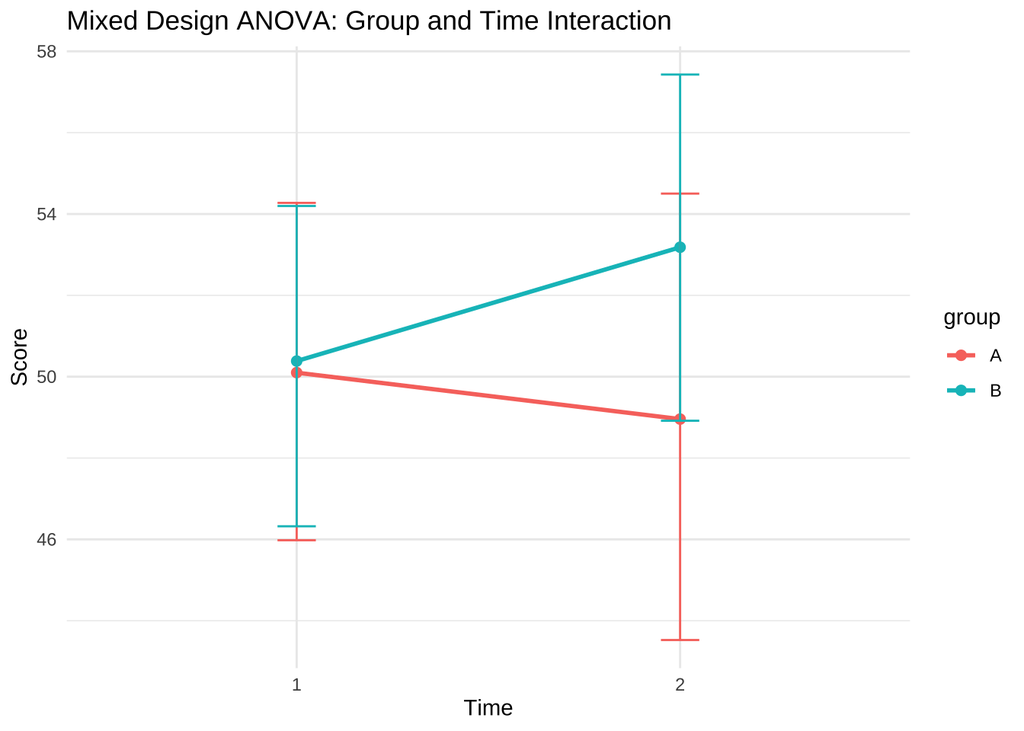

```r
# 4-可视化：绘制组间和组内因素的交互效应
ggplot(data, aes(x = time, y = score, color = group, group = group)) +
  stat_summary(fun = mean, geom = "line", size = 1) +
  stat_summary(fun = mean, geom = "point", size = 2) +
  stat_summary(fun.data = mean_cl_boot, geom = "errorbar", width = 0.1) +
  labs(title = "Mixed Design ANOVA: Group and Time Interaction", x = "Time", y = "Score") +
  theme_minimal()
```

### 结果解释

- **混合设计方差分析结果**：通过`aov_car()`函数进行混合设计方差分析，`summary()`函数输出方差分析的结果，包括组间主效应、组内主效应和交互效应的F值和显著性水平。
- **可视化结果**：通过绘制组间因素（组别）和组内因素（时间）之间的交互效应，可以直观展示不同组别在不同时间点上的表现差异。若交互效应显著，表明不同组别在时间上的变化模式不同。

### 结果的可视化

通过绘制组内和组间因素的交互图，可以直观地看到不同组别在不同时间点上的变化趋势，从而帮助解释组间和组内因素之间的关系。

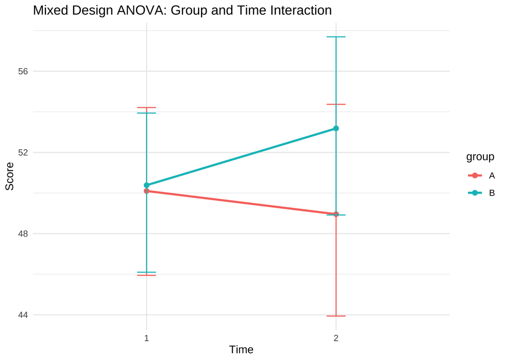

```r
# 使用ggplot2包绘制组间和组内因素的交互效应
ggplot(data, aes(x = time, y = score, color = group, group = group)) +
  stat_summary(fun = mean, geom = "line", size = 1) +
  stat_summary(fun = mean, geom = "point", size = 2) +
  stat_summary(fun.data = mean_cl_boot, geom = "errorbar", width = 0.1) +
  labs(title = "Mixed Design ANOVA: Group and Time Interaction", x = "Time", y = "Score") +
  theme_minimal()
```

## 7 小结

- 混合设计方差分析是一种用于分析组内和组间因素同时存在的实验设计的统计方法，适用于多因素实验和重复测量数据。
- 混合设计方差分析可以检测组间主效应、组内主效应以及交互效应，帮助研究人员更全面地理解实验中的效应。
- 虽然混合设计方差分析具有很强的适用性，但对数据的要求较高，且分析和解释相对复杂。
- 可以通过R中的`afex`包进行混合设计方差分析，并结合可视化工具展示组内和组间因素的交互效应。